# simple_example_using_migration_and_fst

```r
library(slimr)
library(adegenet)
library(dartR)
```

```r
library(ggplot2)
library(purrr)
library(furrr)
set.seed(123456)
```

This is a SLiM script that loads a matrix of migration values from a file (~/Desktop/migration.csv). This is just an example to show what a SLiM version would looks like. Below this, we write the equivalent script in `slimr`.

```
initialize() {
  initializeMutationRate(1e-7);
  initializeMutationType("m1", 0.5, "f", 0.0);
  initializeGenomicElementType("g1", m1, 1.0);
  initializeGenomicElement(g1, 0, 99999);
  initializeRecombinationRate(1e-8);
}

1 {
  for (i in 1:3)
    sim.addSubpop(i, 1000);
  subpops = sim.subpopulations;
  lines = readFile("~/Desktop/migration.csv");
  lines = lines[substr(lines, 0, 1) != "//"];
  for (line in lines)
  {
    fields = strsplit(line, ",");
    i = asInteger(fields[0]);
    j = asInteger(fields[1]);
    m = asFloat(fields[2]);
    if (i != j)
    {
      p_i = subpops[subpops.id == i];
      p_j = subpops[subpops.id == j];
      p_j.setMigrationRates(p_i, m);
    }
  }
}

10000 late() { sim.outputFull(); }
```

```r
slim_script(
  slim_block(initialize(), {
    initializeMutationRate(1e-7);
    initializeMutationType("m1", 0.5, "f", 0.0);
    initializeGenomicElementType("g1", m1, 1.0);
    initializeGenomicElement(g1, 0, 99999);
    initializeRecombinationRate(1e-8);
  }),
  slim_block(1, {
    for (i in 1:3) {
      sim.addSubpop(i, 1000);
    }
    subpops = sim.subpopulations;
    lines = readFile("~/Desktop/migration.csv");
    lines = lines[substr(lines, 0, 1) != "//"];
    for (line in lines) {
      fields = strsplit(line, ",");
      i = asInteger(fields[0]);
      j = asInteger(fields[1]);
      m = asFloat(fields[2]);
      if (i != j) {
        p_i = subpops[subpops.id == i];
        p_j = subpops[subpops.id == j];
        p_j.setMigrationRates(p_i, m);
      }
    }
  }),
  slim_block(10000, late(), {
    sim.outputFull();
  })
) -> script_1

script_1
```

```
#> <slimr_script[3]>
#> block_init:initialize() {
#>     initializeMutationRate(1e-07);
#>     initializeMutationType("m1", 0.5, "f", 0);
#>     initializeGenomicElementType("g1", m1, 1);
#>     initializeGenomicElement(g1, 0, 99999);
#>     initializeRecombinationRate(1e-08);
#> }
#>
#> block_2:1 early() {
#>     for (i in 1:3) {
#>         sim.addSubpop(i, 1000);
#>     }
#>     subpops = sim.subpopulations;
#>     lines = readFile("~/Desktop/migration.csv");
#>     lines = lines[substr(lines, 0, 1) != "//"];
#>     for (line in lines) {
#>         fields = strsplit(line, ",");
#>         i = asInteger(fields[0]);
#>         j = asInteger(fields[1]);
#>         m = asFloat(fields[2]);
#>         if (i != j) {
#>             p_i = subpops[subpops.id == i];
#>             p_j = subpops[subpops.id == j];
#>             p_j.setMigrationRates(p_i, m);
#>         }
#>     }
#> }
#>
#> block_3:10000 late() {
#>     sim.outputFull();
#> }
```

```r
disp_mat <- matrix(c(1, 1, 0.78,
                     1, 2, 0.10,
                     1, 3, 0.12,
                     2, 1, 0.01,
                     2, 2, 0.96,
                     2, 3, 0.03,
                     3, 1, 0.33,
                     3, 2, 0.17,
                     3, 3, 0.5),
                   ncol = 3, byrow = TRUE)

slim_script(
  slim_block(initialize(), {
    setSeed(123456);
    initializeMutationRate(2e-6);
    initializeMutationType("m1", 0.5, "f", 0.0);
    initializeGenomicElementType("g1", m1, 1.0);
    initializeGenomicElement(g1, 0, 99999);
    initializeRecombinationRate(1e-8);
  }),
  slim_block(1, {
    for (i in 1:3) {
      sim.addSubpop(i, 100);
    }
    subpops = sim.subpopulations;

    disp_mat = slimr_inline(disp_mat)

    for (line in seqLen(nrow(disp_mat))) {
      i = asInteger(disp_mat[line, 0]);
      j = asInteger(disp_mat[line, 1]);
      m = asFloat(disp_mat[line, 2]);
      if (i != j) {
        p_i = subpops[subpops.id == i];
        p_j = subpops[subpops.id == j];
        p_j.setMigrationRates(p_i, m);
      }
    }
  }),
  slim_block(100000, late(), {
    slimr_output(sim.outputFull(), "final_output");
  })
) -> script_2

script_2
```

```
#> <slimr_script[3]>
#> block_init:initialize() {
#>     setSeed(123456);
#>     initializeMutationRate(2e-06);
#>     initializeMutationType("m1", 0.5, "f", 0);
#>     initializeGenomicElementType("g1", m1, 1);
#>     initializeGenomicElement(g1, 0, 99999);
#>     initializeRecombinationRate(1e-08);
#> }
#>
#> block_2:1 early() {
#>     for (i in 1:3) {
#>         sim.addSubpop(i, 100);
#>     }
#>     subpops = sim.subpopulations;
#>     disp_mat = {. = matrix(c(1, 1, 1, 2, 2, 2, 3, 3, 3, 1, ...), nrow = 9, ncol = 3)}
#>     for (line in seqLen(nrow(disp_mat))) {
#>         i = asInteger(disp_mat[line, 0]);
#>         j = asInteger(disp_mat[line, 1]);
#>         m = asFloat(disp_mat[line, 2]);
#>         if (i != j) {
#>             p_i = subpops[subpops.id == i];
#>             p_j = subpops[subpops.id == j];
#>             p_j.setMigrationRates(p_i, m);
#>         }
#>     }
#> }
#>
#> block_3:1e+05 late() {
#>     {sim.outputFull() -> final_output}
#> }
```

We can see that the whole matrix has been embedded in the SLiM script by running `as_slim_text` on this `slimr_script` object. This is the script that will actually be run by SLiM.

```r
cat(as_slim_text(script_2))
```

```
#> initialize() {
#>     setSeed(123456);
#>     initializeMutationRate(2e-06);
#>     initializeMutationType("m1", 0.5, "f", 0);
#>     initializeGenomicElementType("g1", m1, 1);
#>     initializeGenomicElement(g1, 0, 99999);
#>     initializeRecombinationRate(1e-08);
#> }
#>
#> 1 early() {
#>     for (i in 1:3) {
#>         sim.addSubpop(i, 100);
#>     }
#>     subpops = sim.subpopulations;
#>     disp_mat = matrix(c(1, 1, 1, 2, 2, 2, 3, 3, 3, 1, 2, 3, 1, 2, 3, 1, 2, 3, 0.78, 0.1, 0.12, 0.01, 0.96, 0.03, 0.33, 0.17, 0.5), nrow = 9, ncol = 3);
#>     for (line in seqLen(nrow(disp_mat))) {
#>         i = asInteger(disp_mat[line, 0]);
#>         j = asInteger(disp_mat[line, 1]);
#>         m = asFloat(disp_mat[line, 2]);
#>         if (i != j) {
#>             p_i = subpops[subpops.id == i];
#>             p_j = subpops[subpops.id == j];
#>             p_j.setMigrationRates(p_i, m);
#>         }
#>     }
#> }
#>
#> 1e+05 late() {
#>     if (community.tick%1 == 0) {
#>         cat("\n<slimr_out:start>\n" + paste(community.tick) + ",'" + "final_output" + "','" + "sim.outputFull()" + "','" + "slim_output','");
#>         sim.outputFull();
#>         cat("'\n<slimr_out:end>\n");
#>     }
#> }
```

Now let’s see if we can run it.

```r
results <- slim_run(script_2, throw_error = TRUE)
```

```
#>
#>
#> Simulation finished with exit status: 0
#>
#> Success!
```

Looks like it worked. We can get the resulting genomic data from the returned object and convert it into a genlight object using the `slim_extract_genlight()` function. Then we can plot the results.

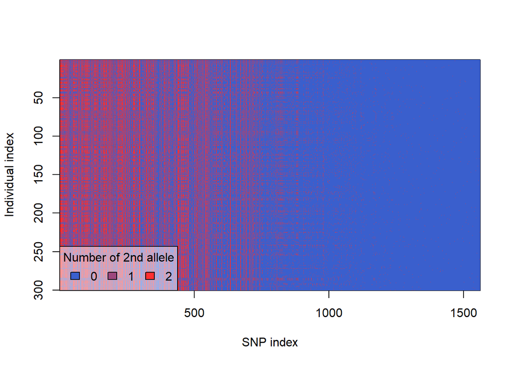

```r
library(dartR)

inds <- slim_extract_genlight(results, "final_output")
ploidy(inds) <- 2
plot(inds)
```

Note that the SNPs are ordered by their mutation id, which should roughly correspond to their order of origination, so the leftmost mutations are the oldest, the rightmost the youngest. Using a genlight object we can calculate a lot of population genetics metrics easily using the package `dartR`. Let’s calculate Fst for example.

```r
p_fst <- dartR::gl.fst.pop(inds, nboots = 1, verbose = 0)
p_fst
```

```
#>              p2         p3 p1
#> p2           NA         NA NA
#> p3 0.0005873432         NA NA
#> p1 0.0139928734 0.00888913 NA
```

```r
## convert migration rates into pairwise matrix using igraph
library(igraph)
overall_mig_rates <- disp_mat %>%
  as.data.frame() %>%
  igraph::graph_from_data_frame() %>%
  igraph::as.undirected(mode = "collapse", edge.attr.comb = "mean") %>%
  igraph::as_adjacency_matrix(type = "lower", attr = "V3", sparse = FALSE)

diag(overall_mig_rates) <- NA
overall_mig_rates[upper.tri(overall_mig_rates)] <- NA

p_fst
```

```
#>              p2         p3 p1
#> p2           NA         NA NA
#> p3 0.0005873432         NA NA
#> p1 0.0139928734 0.00888913 NA
```

```r
overall_mig_rates
```

```
#>       1   2  3
#> 1    NA  NA NA
#> 2 0.055  NA NA
#> 3 0.225 0.1 NA
```

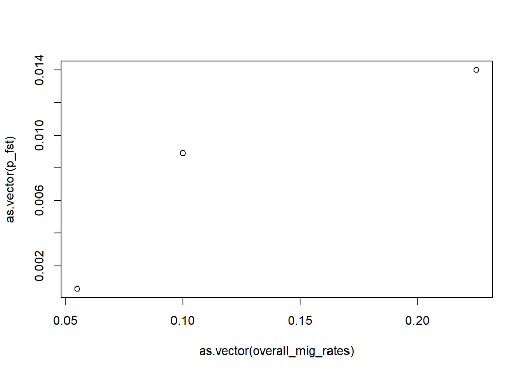

```r
plot(as.vector(overall_mig_rates), as.vector(p_fst))
```

```r
slim_script(
  slim_block(initialize(), {
    initializeMutationRate(2e-6);
    initializeMutationType("m1", 0.5, "f", 0.0);
    initializeGenomicElementType("g1", m1, 1.0);
    initializeGenomicElement(g1, 0, 99999);
    initializeRecombinationRate(1e-8);
  }),
  slim_block(1, {
    sim.addSubpop("p1", slimr_template("pop_size", default = 100));
    sim.addSubpop("p2", ..pop_size..);
    p1.setMigrationRates(p2, slimr_template("m", default = 0.1));
    p2.setMigrationRates(p1, ..m..);
  }),
  slim_block(10000, late(), {
    slimr_output(sim.outputFull(), "final_output");
  })
) -> script_3

script_3
```

```
#> <slimr_script[3]>
#> block_init:initialize() {
#>     initializeMutationRate(2e-06);
#>     initializeMutationType("m1", 0.5, "f", 0);
#>     initializeGenomicElementType("g1", m1, 1);
#>     initializeGenomicElement(g1, 0, 99999);
#>     initializeRecombinationRate(1e-08);
#> }
#>
#> block_2:1 early() {
#>     sim.addSubpop("p1", ..pop_size..);
#>     sim.addSubpop("p2", ..pop_size..);
#>     p1.setMigrationRates(p2, ..m..);
#>     p2.setMigrationRates(p1, ..m..);
#> }
#>
#> block_3:10000 late() {
#>     {sim.outputFull() -> final_output}
#> }
#> This slimr_script has templating in block(s) block_2 for
#> variables pop_size and m.
```

So in the above script we now have a placemarker for a `pop_size` and a `m` parameter. We specified this using the `slimr_template` function directly inserted into the SLiM code. We also demonstrate a trick to reduce typing. We only have to use the `slimr_template` function once for a given variable, subsequent references to the same variable can be specified directly using the `..x..` notation. Now to generate a script with the templated variables replaced with values of our choosing, we use the `slim_script_render` function. Here is an example:

```r
example_script <- slim_script_render(script_3, template = list(pop_size = 50, m = 0.05))
example_script
```

```
#> <slimr_script[3]>
#> block_init:initialize() {
#>     initializeMutationRate(2e-06);
#>     initializeMutationType("m1", 0.5, "f", 0);
#>     initializeGenomicElementType("g1", m1, 1);
#>     initializeGenomicElement(g1, 0, 99999);
#>     initializeRecombinationRate(1e-08);
#> }
#>
#> block_2:1 early() {
#>     sim.addSubpop("p1", 50);
#>     sim.addSubpop("p2", 50);
#>     p1.setMigrationRates(p2, 0.05);
#>     p2.setMigrationRates(p1, 0.05);
#> }
#>
#> block_3:10000 late() {
#>     {sim.outputFull() -> final_output}
#> }
```

We can also pass a `data.frame` to `slim_script_render` which will allow us to generate many scripts at once, let’s setup a large number of scripts to explore different values of our two parameters.

```r
n_reps <- 300

param_df <- data.frame(pop_size = sample(5:100, n_reps, replace = TRUE),
                                                         m = runif(n_reps, 0, 0.5))

script_list <- slim_script_render(script_3,
                                   template = param_df)

script_list
```

```
#> <slimr_script_coll[300]>
#> <1>
#>
#> block_init:initialize() {
#>     initializeMutationRate(2e-06);
#>     initializeMutationType("m1", 0.5, "f", 0);
#>     initializeGenomicElementType("g1", m1, 1);
#>     initializeGenomicElement(g1, 0, 99999);
#>     initializeRecombinationRate(1e-08);
#> }
#>
#> block_2:1 early() {
#>     sim.addSubpop("p1", 85);
#>     sim.addSubpop("p2", 85);
#>     p1.setMigrationRates(p2, 0.379254172206856);
#>     p2.setMigrationRates(p1, 0.379254172206856);
#> }
#>
#> block_3:10000 late() {
#>     {sim.outputFull() -> final_output}
#> }
#>
#> <2>
#>
#> block_init:initialize() {
#>     initializeMutationRate(2e-06);
#>     initializeMutationType("m1", 0.5, "f", 0);
#>     initializeGenomicElementType("g1", m1, 1);
#>     initializeGenomicElement(g1, 0, 99999);
#>     initializeRecombinationRate(1e-08);
#> }
#>
#> block_2:1 early() {
#>     sim.addSubpop("p1", 41);
#>     sim.addSubpop("p2", 41);
#>     p1.setMigrationRates(p2, 0.26800632593222);
#>     p2.setMigrationRates(p1, 0.26800632593222);
#> }
#>
#> block_3:10000 late() {
```

[output cut: 13 more lines]

```
#> block_2:1 early() {
#>     sim.addSubpop("p1", 37);
#>     sim.addSubpop("p2", 37);
#>     p1.setMigrationRates(p2, 0.0882677737390622);
#>     p2.setMigrationRates(p1, 0.0882677737390622);
#> }
#>
#> block_3:10000 late() {
#>     {sim.outputFull() -> final_output}
#> }
#>
#>
#> <...>
#>
#> and 297 more.
```

This function returns a `slimr_script_coll` object, or a slimr script collection. We can now use `slim_run` on this object, which will run every script in the collection, one after the other, and collect the results. We can specify a `parallel = TRUE` argument to run the scripts in parallel. `slimr` uses the `future` package for parallelization. This means that the user must specify a future `plan` prior to running `slim_run` which will setup the workers to be used by `slimr`. If you want to use parallelization with `slimr`, we recommend you familiarize yourself with the `future` package. If in doubt `future::plan(future::multisession)` is the most general purpose specification which should work well on all platforms (and is the recommended plan by future for best stability of parallelization). You must also ensure the `future` and `furrr` packages are installed for this functionality to work. Let’s try running these:

```r
start_time <- Sys.time()
if(requireNamespace("furrr", quietly = TRUE)) {

  future::plan(future::multisession)

  all_results <- slim_run(script_list, parallel = TRUE, progress = TRUE, throw_error = TRUE)

}
```

Cool! First let’s check if all simulation completed without error:

```r
errors <- purrr::map_lgl(all_results,
                         ~length(.x$error) > 0)
sum(errors)
```

```
#> [1] 0
```

Let’s extract all the genomic data into genlight objects so we can easily calculate Fst. Since this might also take a little while we will parallelize this extraction as well using `furrr` (since we already set a `future` plan, and `furrr` uses `future` under the hood). Just in case any simulations give us trouble, we will wrap the extraction in `try()` so that the whole thing doesn’t fail for one error.

```r
all_gl <- furrr::future_map(all_results,
                     ~suppressWarnings(suppressMessages(try(slim_extract_genlight(.x, "final_output")))),
                     .progress = TRUE)
```

Any errors?

```r
errored <- which(sapply(all_gl, function(x) class(x) == "try-error"))
errored
```

```
#> integer(0)
```

```r
purrr::map(errored,
           ~all_results[[.x]]$output_data$data)
```

```
#> list()
```

```r
if(length(errored) > 0) {
  all_gl <- all_gl[-errored]
}

all_fsts <- furrr::future_map_dbl(all_gl,
                                  ~ {
                                    ploidy(.x) <- 2
                                    dartR::gl.fst.pop(.x, nboots = 1, verbose = 0)[2, 1]
                                  },
                                  .progress = TRUE)
```

[output not shown]

[output cut: 137 more lines]

[output not shown]

```r
end_time <- Sys.time()

end_time - start_time
```

```
#> Time difference of 3.135381 mins
```

```r
cat("Total Duration:", end_time - start_time)
```

```
#> Total Duration: 3.135381
```

Firstly, negative values of Fst are incorrect, and usually reflect numerical inaccuracy around zero, so we will set negative Fst values to zero. Then let’s look at the distribution.

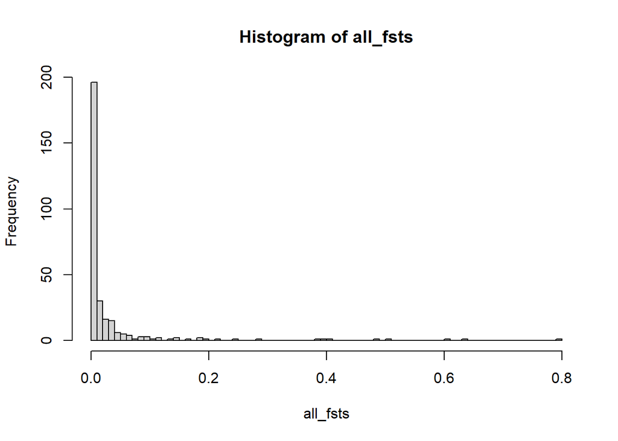

```r
all_fsts[all_fsts < 0] <- 0.0
hist(all_fsts, breaks = 100)
```

So how is Fst related to migration rate and population size? We can get an idea by running a simple linear model. Then we will do plots.

```r
if(length(errored) > 0) {
  param_df <- param_df[-errored, ]
}

fst_dat <- param_df %>%
  dplyr::mutate(fst = all_fsts,
                pop_size_st = (pop_size - mean(pop_size)) / sd(pop_size),
                m_st = (m - mean(m)) / sd(m))

mod <- lm(fst ~ pop_size_st*m_st, data = fst_dat)
summary(mod)
```

```
#>
#> Call:
#> lm(formula = fst ~ pop_size_st * m_st, data = fst_dat)
#>
#> Residuals:
#>      Min       1Q   Median       3Q      Max
#> -0.11246 -0.03685 -0.00821  0.01515  0.63736
#>
#> Coefficients:
#>                   Estimate Std. Error t value Pr(>|t|)
#> (Intercept)       0.031889   0.004795   6.651 1.40e-10 ***
#> pop_size_st      -0.014542   0.004826  -3.013  0.00281 **
#> m_st             -0.039037   0.004827  -8.087 1.59e-14 ***
#> pop_size_st:m_st  0.015742   0.004737   3.323  0.00100 **
#> ---
#> Signif. codes:  0 '***' 0.001 '**' 0.01 '*' 0.05 '.' 0.1 ' ' 1
#>
#> Residual standard error: 0.08304 on 296 degrees of freedom
#> Multiple R-squared:  0.2186, Adjusted R-squared:  0.2107
#> F-statistic: 27.61 on 3 and 296 DF,  p-value: 9.061e-16
```

We can demonstrate the interaction by splitting our data into population size bins and plotting the migration rate relationship as separate lines for each bin.

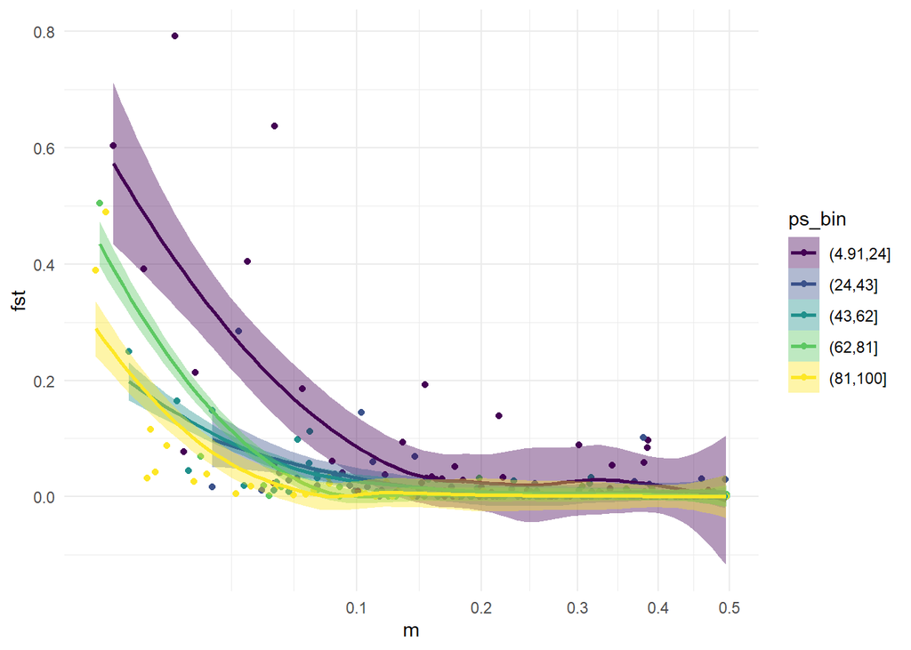

```r
fst_dat <- fst_dat %>%
  dplyr::mutate(ps_bin = cut(pop_size, 5, ordered_result = TRUE))

ggplot(fst_dat, aes(m, fst)) +
  geom_point(aes(colour = ps_bin)) +
  geom_smooth(aes(colour = ps_bin, fill = ps_bin)) +
  scale_x_sqrt() +
  theme_minimal()
```